# Aula 11 - Econometria de Séries Temporais

João Ricardo F. de Lima

16 de maio de 2022.

# 1 VAR ESTRUTURAL

A abordagem estrutural para o modelo VAR (VAR Estrutural) permite a análise de relações contemporâneas entre as variáveis estabelecidas com base na teoria econômica. É necessário desenvolver modelo teórico que forneça embasamento das hipóteses que fundamentam as restrições a serem impostas nas relações contemporâneas e que levam à identificação do modelo empírico permitindo sua estimação.

Relembrando o Modelo VAR, tem-se:

Para definir o modelo VAR pode-se apresentar uma especificação bivariada simples. A idéia é que não sabendo se há causalidade mútua, se parte de um modelo em que as inovações contemporâneas de um processo afetam o outro.

$$y_{1,t}=\alpha_1-\delta_2y_{2,t}+\beta_1y_{1,t-1}+\beta_2y_{2,t-1}+\epsilon_{1,t}$$

$$y_{2,t}=\alpha_2-\delta_1y_{1,t}+\beta_2y_{2,t-1}+\beta_1y_{1,t-1}+\epsilon_{2,t}$$

No sistema acima, os termos $y_{1,t}$ e $y_{2,t}$ representam a dinâmica contemporânea, relaxando a hipótese de restrição de *feedback*.

O modelo acima está no denominado modelo estrutural, devido a presença do termo contemporâneo no lado direito de cada equação.

Para colocá-lo na forma reduzida, se escreve o modelo na forma matricial a partir do rearranjo;

$$y_{1,t}+\delta_2y_{2,t}=\alpha_1+\beta_1y_{1,t-1}+\beta_2y_{2,t-1}+\epsilon_{1,t}$$

$$y_{2,t}+\delta_1y_{1,t}=\alpha_2+\beta_2y_{2,t-1}+\beta_1y_{1,t-1}+\epsilon_{2,t}$$
a partir do qual se obtém:

$$\left[\begin{array}{cc}
1 & \delta_2\\
\delta_1 & 1
\end{array}\right] \left[\begin{array}{c}
y_1 \\
y_2
\end{array}\right]_t = \left[\begin{array}{c}
\alpha_1\\
\alpha_2
\end{array}\right]+ \left[\begin{array}{cc}
\beta_1 & \beta_2 \\
\beta_2 & \beta_1
\end{array}\right] \left[\begin{array}{c}
y_1 \\
y_2
\end{array}\right]_{t-1}+\left[\begin{array}{c}
\epsilon_1 \\
\epsilon_2
\end{array}\right]_t$$

que pode ser simplificado como

$$Ay_t=\alpha+B^*y_{t-1}+\epsilon_t$$

se a equação acima for multiplicada pela inversa da Matriz A, ou seja,

$$A^{-1}=\left[\begin{array}{cc}
1 & \delta_2\\
\delta_1 & 1
\end{array}\right]^{-1}= \frac{1}{1-\delta_1\delta_2}\left[\begin{array}{cc}
1 & -\delta_1\\
-\delta_2 & 1
\end{array}\right]$$

De onde se obtém

$$y_t=a+By_{t-1}+e_t,$$

a chamada forma reduzida, em que $a=A^{-1}\alpha$, $B=A^{-1}B^*$ e $e_t=A^{-1}\epsilon_t$

Apesar do modelo VAR conseguir captar as características dinâmicas de séries temporais multivariadas, identifica-se a necessidade de transformar a matriz de variância e covariâncias dos erros para se ter choques ortogonais, isto é, não correlacionados, para a análise correta das funções de impulso-resposta e decomposição do erro de previsão.

Quando os erros são contemporaneamente correlacionados os coeficientes não refletem de forma adequada os efeitos dos choques nas variáveis do sistema. Assim, os erros devem ser ortogonalizados de modo a apresentarem matriz de variâncias e covariâncias diagonal (ausência de covariância).

A ortogonalização consiste em uma transformação dos erros gerando outro vetor de erros com matriz de variâncias e covariâncias diagonal. No entanto, esta transformação envolve modificar todo o modelo o que traz consequências para o relacionamento contemporâneo entre as variáveis.

Considere $e_t$ os choques/inovações originais do VAR (erros correlacionados):

$$Var-Cov(e_t) = E(e_te_t')= \Omega$$

$$\Omega = \left[\begin{array}{cc}
Var(e_1) & Cov(e_1e_2) \\
Cov(e_1e_2) & Var(e_2)
\end{array}\right] =\left[\begin{array}{cc}
\sigma^2_1 & \sigma_{12} \\
\sigma_{21} & \sigma^2_2
\end{array}\right]$$

É necessária um transformação em $e_t$, multiplicando o por uma matriz P:

$$\mu_t=Pe_t,$$

$$\mu_t = \left[\begin{array}{c}
P
\end{array}\right]\left[\begin{array}{c}
e_{1t} \\
e_{2t}
\end{array}\right]$$

$$Var-Cov(\mu_t)=E(\mu_t\mu_t')=E(Pe_te_t'P')$$

onde $e_te_t'$ é a variancia-covariância

$$E(Pe_te_t'P') = E(P \Omega P')=\Sigma(diagonal)$$

$$Var-Cov(\mu_t)= \left[\begin{array}{cc}
Var(\mu_1) & 0 \\
0 & Var(\mu_2)
\end{array}\right]$$

Esta matriz P tem algumas características:

1. Quadrada com dimensão igual ao número de equações/variáveis
2. Tem que ter determinante diferente de zero (não singular)
3. Fornecer uma $\mu_t$ ortogonal

Quando se multiplica o modelo VAR por P se tem um novo modelo, com um novo erro $\mu_t$ e com o lado esquerdo da equação incorporando relações contemporâneas entre as variáveis do sistema. Tal modelo é conhecido como VAR Estrutural que permite a análise de funções impulso-resposta ortogonais, decomposição da variância do erro de previsão e estimativas de coeficientes de relações contemporâneas entre as variáveis.

Existem várias opções de P. Uma delas é a **Decomposição de Cholesky**. Qual a necessidade de fazer decomposição de Cholesky? Observe que na forma estrutural existem 10 parametros para serem estimados: 8 coeficientes e mais 2 variâncias de erros.

$$\left[\begin{array}{cc}
1 & \delta_2\\
\delta_1 & 1
\end{array}\right] \left[\begin{array}{c}
y_1 \\
y_2
\end{array}\right]_t = \left[\begin{array}{c}
\alpha_1\\
\alpha_2
\end{array}\right]+ \left[\begin{array}{cc}
\beta_1 & \beta_2 \\
\beta_2 & \beta_1
\end{array}\right] \left[\begin{array}{c}
y_1 \\
y_2
\end{array}\right]_{t-1}+\left[\begin{array}{c}
\epsilon_1 \\
\epsilon_2
\end{array}\right]_t$$

Contudo, na forma reduzida do Modelo VAR apenas 6 parâmetros (a=2; B=4) podem ser estimados além da $Var(\epsilon_1)$, da $Var(\epsilon_2)$ e a $Cov(\epsilon_1,\epsilon_2)$. Isto gera um problema de **identificação**, as estimativas do modelo estrutural não podem ser recuperadas com as estimativas do modelo reduzido.

$$y_t=a+By_{t-1}+e_t,$$

em que $a=A^{-1}\alpha$, $B=A^{-1}B^*$ e $e_t=A^{-1}\epsilon_t$.

Para se ter **identificação** é preciso impor restrições no sistema estrutural. O número de restrições necessário para alcançar identificação depende da relação entre o número de coeficientes estimados na forma reduzida e o número de coeficientes a serem obtidos na forma estrutural; é um problema de número de incógnitas e de número de equações (relações).

Uma solução para isto é usar a decomposição de Cholesky forçando que o triangulo superir seja igual a zero. Contudo, com dados reais o recomendado é que se use a Teoria Econômica para definir as restrições.

## 1.1 Identificação

Para estimar o SVAR tem-se que resolver primeiro o problema de identificação. Considere o modelo SVAR sem intercepto

$$AY_t=\sum AY_{t-1}+Bu_t$$

Se multiplicarmos tudo por $A^{-1}$, tem-se

$$Y_t=\sum \Phi Y_{t-1}+a_t$$

em que $a_t=A^{-1}Bu_t$ ou $Aa_t=Bu_t$, um VAR padrão. Observe que $a_t$ são os erros do modelo VAR na sua forma reduzida (correlacionados) enquanto que $u_t$ são os erros da forma estrutural (não correlacionados).

Para conseguir a partir das estimativas da matriz de variância e covariância de $a$ obter as estimativas dos coeficientes de **A** e **B** do modelo estrutural é preciso impor restrições nas matrizes **A** e **B**. O número de restrições necessário para alcançar identificação depende da relação entre o número de coeficientes estimados na forma reduzida e o número de coeficientes a serem obtidos na forma estrutural. É um problema de número de incógnitas e de número de equações (relações) semelhante à condição de ordem em equações simultâneas.

Elementos a serem identificados: Temos $k^2$ elementos de A mais k elementos da matriz B (diagonal) de variâncias dos erros do modelo estrutural, dando um total de $k^2+k$. Contudo, impondo-se a restrição de que a matriz de relações contemporâneas tenha $1's$ na diagonal, tem-se $(k^2-k)+k=k^2$ valores desconhecidos no modelo estrutural.

Elementos observados/estimados: São os valores da matriz de variâncias e covariâncias dos erros $(\hat \Omega)$ do modelo VAR padrão (forma reduzida). Esta matriz é simétrica e terá $(k^2+k)/2$ elementos livres.

Identificação: Para identificar $(k^2)$ coeficientes desconhecidos a partir dos $(k^2+k)/2$ valores de $(\hat \Omega)$, será necessário impor $k^2-[(k^2+k)/2]=(k^2-k)/2$ restrições adicionais no sistema.

As restrições são impostas na matriz $A$. Para a maioria dos problemas são restrições de exclusão com zeros nas posições que representam ausência de relação contemporânea, ou seja, nas posições de coeficientes que não serão estimados.

Três situações com relação à condição de identificação do sistema:

1. Sistema exatamente identificado – quando o número de restrições em $A$ for igual a (k^2-k)/2,
2. Sistema superidentificado – quando o número de restrições for maior que $(k^2-k)/2$,
3. Sistema subidentificado- quando o número de restrições for menor que $(k^2-k)/2)$.

O sistema estrutural é estimável ou identificado quando for exatamente identificado ou superidentificado.

Com base em $Aa_t=Bu_t$ e dependendo das restrições impostas, três tipos de modelos SVAR podem ser definidos:

**MODELO A**

Neste modelo a idéia é modelar as relações contemporâneas entre as variáveis diretamente pela matriz $A$ considerando $B=I_k$, isto é:

$$Aa_t=u_t$$

o que reduz o número de valores desconhecidos de $2k^2$ para $k^2$, pois só tem-se a matriz A a ser identificada. Assim, o número mínimo de restrições para identificação será $k(k−1)/2$.

**MODELO B**

Neste modelo, ao invés de modelar diretamente as relações contemporâneas entre as variáveis, especifica-se as relações entre os erros identificando-se os choques estruturais diretamente pelos choques da forma reduzida. A matriz $A$ é considerada identidade, isto é, $A=I_k$. Logo,

$$a_t=Bu_t$$

Ou seja, os erros da forma reduzida são funções lineares dos erros estruturais. O número mínimo de restrições para identificação também é $k(k−1)/2$.

**MODELO AB**

É o modelo que considera os dois tipos de restrições simultâneamente, ou seja:

$$Aa_t=Bu_t$$

Como A e B têm $k^2$ elementos cada, tem-se que impor no mínimo $k2+k(k−1)/2$ restrições para identificação.

## 1.2 Restrições de longo prazo à la Blanchard-Quah

Blanchard e Quah (1989) propõem uma abordagem, que não requer a imposição direta de restrições nas matrizes estruturais A ou B. Em vez disso, as inovações estruturais podem ser identificadas observando os efeitos acumulados dos choques e colocando zero restrições nessas relações acumuladas, que morrem e se tornam zero no longo prazo.

# 2 Estimação

## 2.1 Dados

Para esta ilustração geramos um conjunto de dados artificiais com três variáveis endógenas, que seguem o processo de geração de dados

$$y_t = A_1Y_{t-1}+B \epsilon_t$$

onde,

$$A=\left[\begin{array}{ccc}
0.3 & 0.12 &0.69\\
0 & 0.3 & 0.48 \\
0.24 & 0.24 & 0.3
\end{array}\right];$$

$$B=\left[\begin{array}{ccc}
1 & 0 &0\\
-0,14 & 1 & 0 \\
-0.06 & 0.39 & 1
\end{array}\right];$$
$$\epsilon_t \sim N(0,I_3)$$

O pacote `vars` (Pfaff, 2008) fornece funções para estimar VARs estruturais em R. O workflow é dividido em duas etapas, onde a primeira consiste em estimar um modelo VAR padrão usando a função VAR.

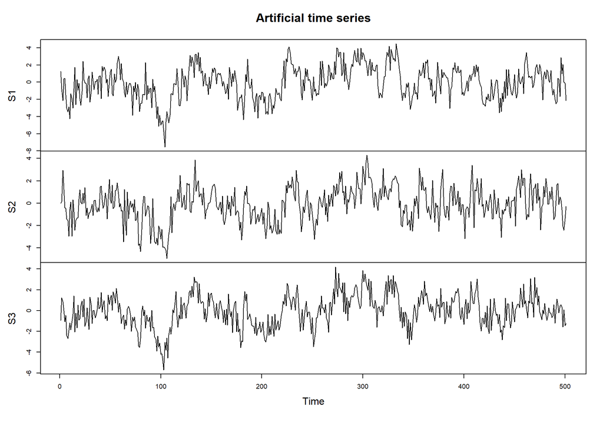

```r
# https://www.r-econometrics.com/timeseries/svarintro/

library(vars)

# Reset random number generator for reproducibility
set.seed(24579)

tt <- 500 # Number of time series observations

# Coefficient matrix
A_1 <- matrix(c(0.3, 0, 0.24,
                0.12, 0.3, 0.24,
                0.69, 0.48, 0.3), 3)

# Structural coefficients
B <- diag(1, 3)
B[lower.tri(B)] <- c(-0.14, -0.06, 0.39)

# Generate series
series <- matrix(rnorm(3, 0, 1), 3, tt + 1) # Raw series with zeros
for (i in 2:(tt + 1)){
  series[, i] <- A_1 %*% series[, i - 1] +  B %*% rnorm(3, 0, 1)
}

series <- ts(t(series)) # Convert to time series object
dimnames(series)[[2]] <- c("S1", "S2", "S3") # Rename variables

# Plot the series
plot.ts(series, main = "Artificial time series")
```

```r
# Estimate reduced form VAR
var_est <- VAR(series, p = 1, type = "none")

var_est
```

```
#
# VAR Estimation Results:
# =======================
#
# Estimated coefficients for equation S1:
# =======================================
# Call:
# S1 = S1.l1 + S2.l1 + S3.l1
#
#     S1.l1     S2.l1     S3.l1
# 0.3288079 0.1124078 0.6809865
#
#
# Estimated coefficients for equation S2:
# =======================================
# Call:
# S2 = S1.l1 + S2.l1 + S3.l1
#
#        S1.l1        S2.l1        S3.l1
# -0.001530688  0.289578440  0.512701274
#
#
# Estimated coefficients for equation S3:
# =======================================
# Call:
# S3 = S1.l1 + S2.l1 + S3.l1
#
#     S1.l1     S2.l1     S3.l1
# 0.2401861 0.2519319 0.3186145
```

Os coeficientes estimados estão razoavelmente próximos dos coeficientes verdadeiros. Na próxima etapa o objeto resultante é utilizado na função SVAR para estimar os diversos modelos estruturais.

**Modelo A**

O modelo A requer a especificação de uma matriz Amat, que contém as restrições $K(K−1)/2$. No exemplo a seguir, cria-ses uma matriz diagonal com uns como elementos diagonais e zeros em seu triângulo superior. Os elementos triangulares inferiores são definidos como NA, o que indica que eles devem ser estimados.

```r
# Estimate structural coefficients
a <- diag(1, 3)
a[lower.tri(a)] <- NA

svar_est_a <- SVAR(var_est, Amat = a, max.iter = 1000)

svar_est_a
```

```
#
# SVAR Estimation Results:
# ========================
#
#
# Estimated A matrix:
#         S1      S2 S3
# S1 1.00000  0.0000  0
# S2 0.18177  1.0000  0
# S3 0.05078 -0.3132  1
```

O resultado não é igual à matriz B, pois estimou-se um modelo A. Para traduzi-lo nos coeficientes estruturais do modelo B, basta obter o inverso da matriz:

```r
solve(svar_est_a$A)
```

```
#            S1        S2 S3
# S1  1.0000000 0.0000000  0
# S2 -0.1817747 1.0000000  0
# S3 -0.1077103 0.3131988  1
```

Os intervalos de confiança para os coeficientes estruturais podem ser obtidos acessando diretamente o respectivo elemento em svar_est_a:

```r
svar_est_a$Ase
```

```
#            S1         S2 S3
# S1 0.00000000 0.00000000  0
# S2 0.04472136 0.00000000  0
# S3 0.04545420 0.04472136  0
```

**Modelo B**

Os modelos B são estimados de maneira semelhante aos modelos A, especificando uma matriz Bmat, que contém restrições na matriz estrutural B. No exemplo a seguir, B é igual a Amat acima.

```r
# Create structural matrix with restrictions
b <- diag(1, 3)
b[lower.tri(b)] <- NA

# Estimate
svar_est_b <- SVAR(var_est, Bmat = b)

# Show result
svar_est_b
```

```
#
# SVAR Estimation Results:
# ========================
#
#
# Estimated B matrix:
#         S1     S2 S3
# S1  1.0000 0.0000  0
# S2 -0.1818 1.0000  0
# S3 -0.1077 0.3132  1
```

```r
# Confidence Intervals of the structural coefficients
svar_est_b$Bse
```

```
#            S1         S2 S3
# S1 0.00000000 0.00000000  0
# S2 0.04472136 0.00000000  0
# S3 0.04686349 0.04472136  0
```